# GDP Growth by Coutnry

¶ ¶

¶ < JACOB FISHER > ¶

## Data and Description

#### 1. Read in the data set, and call the data frame “gdp_data”. Print a summary of the data and make sure the data makes sense. Make sute the class of “gdp_data” is a *data.frame only*. Use the `as.data.frame` command.

```r
gdp <- read.csv("C:/Users/jbren/Desktop/STAT_330/HW_06/GDP_data.csv")
gdp_data <- as.data.frame(gdp)
summary(gdp)
```

```
##   GDPPC_GROWTH       ABSLATIT         AIRDIST         AVELF
##  Min.   :-3.180   Min.   : 0.228   Min.   : 140   Min.   :0.00000
##  1st Qu.: 0.790   1st Qu.: 9.156   1st Qu.:2164   1st Qu.:0.06488
##  Median : 2.080   Median :18.747   Median :4480   Median :0.26253
##  Mean   : 1.820   Mean   :23.211   Mean   :4324   Mean   :0.34761
##  3rd Qu.: 2.732   3rd Qu.:35.953   3rd Qu.:6248   3rd Qu.:0.67123
##  Max.   : 6.910   Max.   :60.212   Max.   :9320   Max.   :0.89025
##       BRIT            BUDDHA            CATH00           CIV72
##  Min.   :0.0000   Min.   :0.00000   Min.   :0.0000   Min.   :0.0000
##  1st Qu.:0.0000   1st Qu.:0.00000   1st Qu.:0.0040   1st Qu.:0.1667
##  Median :0.0000   Median :0.00000   Median :0.0595   Median :0.5000
##  Mean   :0.3182   Mean   :0.04659   Mean   :0.3283   Mean   :0.5095
##  3rd Qu.:1.0000   3rd Qu.:0.00000   3rd Qu.:0.8718   3rd Qu.:0.8333
##  Max.   :1.0000   Max.   :0.95000   Max.   :1.0000   Max.   :1.0000
##      COLONY         CONFUC            DENS60            DENS65C
##  Min.   :0.00   Min.   :0.00000   Min.   :   0.322   Min.   :   0.00
##  1st Qu.:0.75   1st Qu.:0.00000   1st Qu.:  11.508   1st Qu.:  12.93
##  Median :1.00   Median :0.00000   Median :  39.348   Median :  39.62
##  Mean   :0.75   Mean   :0.01557   Mean   : 108.073   Mean   : 146.87
##  3rd Qu.:1.00   3rd Qu.:0.00000   3rd Qu.:  94.115   3rd Qu.:  99.04
##  Max.   :1.00   Max.   :0.60000   Max.   :1178.233   Max.   :3729.29
##     DENS65I           DPOP6090             EAST            ECORG
##  Min.   :  0.000   Min.   :0.002368   Min.   :0.0000   Min.   :0.000
##  1st Qu.:  3.315   1st Qu.:0.015024   1st Qu.:0.0000   1st Qu.:3.000
##  Median : 12.652   Median :0.023928   Median :0.0000   Median :3.000
##  Mean   : 43.371   Mean   :0.021528   Mean   :0.1136   Mean   :3.466
##  3rd Qu.: 32.081   3rd Qu.:0.028389   3rd Qu.:0.0000   3rd Qu.:5.000
##  Max.   :537.029   Max.   :0.035654   Max.   :1.0000   Max.   :5.000
##     ENGFRAC            EUROPE          FERTLDC1           GDE1
##  Min.   :0.00000   Min.   :0.0000   Min.   :0.6487   Min.   :0.00000
##  1st Qu.:0.00000   1st Qu.:0.0000   1st Qu.:1.2410   1st Qu.:0.01100
##  Median :0.00000   Median :0.0000   Median :1.7500   Median :0.01900
##  Mean   :0.08398   Mean   :0.2159   Mean   :1.5620   Mean   :0.02589
##  3rd Qu.:0.00000   3rd Qu.:0.0000   3rd Qu.:1.8718   3rd Qu.:0.03050
##  Max.   :0.97000   Max.   :1.0000   Max.   :2.0794   Max.   :0.16600
##     GDPCH60L        GEEREC1            GGCFD3           GOVNOM1
##  Min.   :5.549   Min.   :0.00410   Min.   :0.00000   Min.   :0.030
##  1st Qu.:6.687   1st Qu.:0.01755   1st Qu.:0.03000   1st Qu.:0.110
##  Median :7.198   Median :0.02310   Median :0.04500   Median :0.145
##  Mean   :7.355   Mean   :0.02441   Mean   :0.05216   Mean   :0.149
```

[output cut: 64 more lines]

```
##  Max.   :21.30   Max.   :1.00000   Max.   :1.0000   Max.   : 0.123214
##      TOTIND          TROPICAR         TROPPOP           WARTIME
##  Min.   :0.0000   Min.   :0.0000   Min.   :0.00000   Min.   :0.00000
##  1st Qu.:0.1431   1st Qu.:0.0000   1st Qu.:0.00000   1st Qu.:0.00000
##  Median :0.2448   Median :0.9653   Median :0.03025   Median :0.00000
##  Mean   :0.2813   Mean   :0.5702   Mean   :0.29998   Mean   :0.06955
##  3rd Qu.:0.3914   3rd Qu.:1.0000   3rd Qu.:0.52925   3rd Qu.:0.08000
##  Max.   :0.8483   Max.   :1.0000   Max.   :1.00000   Max.   :1.00000
##     WARTORN          YRSOPEN          ZTROPICS
##  Min.   :0.0000   Min.   :0.0000   Min.   :0.000
##  1st Qu.:0.0000   1st Qu.:0.0000   1st Qu.:0.000
##  Median :0.0000   Median :0.2200   Median :0.042
##  Mean   :0.3977   Mean   :0.3555   Mean   :0.190
##  3rd Qu.:1.0000   3rd Qu.:0.7300   3rd Qu.:0.335
##  Max.   :1.0000   Max.   :1.0000   Max.   :1.000
```

#### 2. Fit a multiple regression model with all covariates explaining `GDPPC_GROWTH`. Call this model lm_gdp.

```r
gdp_lm <- lm(GDPPC_GROWTH ~ ., data = gdp_data)
summary(gdp_lm)
```

```
##
## Call:
## lm(formula = GDPPC_GROWTH ~ ., data = gdp_data)
##
## Residuals:
##      Min       1Q   Median       3Q      Max
## -1.30152 -0.33856 -0.02593  0.32949  1.31097
##
## Coefficients:
##               Estimate Std. Error t value Pr(>|t|)
## (Intercept)  1.323e+01  8.301e+00   1.593   0.1261
## ABSLATIT    -2.709e-02  5.414e-02  -0.500   0.6220
## AIRDIST     -9.326e-05  2.021e-04  -0.461   0.6492
## AVELF       -3.562e-01  1.363e+00  -0.261   0.7964
## BRIT         3.712e-01  8.331e-01   0.446   0.6605
## BUDDHA       3.198e+00  3.175e+00   1.007   0.3253
## CATH00      -6.318e-01  2.733e+00  -0.231   0.8194
## CIV72       -6.371e-01  1.593e+00  -0.400   0.6933
## COLONY      -5.188e-01  1.405e+00  -0.369   0.7155
## CONFUC       3.227e+00  4.540e+00   0.711   0.4851
## DENS60       6.526e-05  1.833e-03   0.036   0.9719
## DENS65C      3.947e-04  1.305e-03   0.302   0.7653
## DENS65I      1.295e-03  3.437e-03   0.377   0.7101
## DPOP6090     3.581e+01  8.626e+01   0.415   0.6822
## EAST         1.959e+00  1.843e+00   1.063   0.2999
## ECORG       -1.698e-01  2.267e-01  -0.749   0.4621
## ENGFRAC      3.505e-01  1.248e+00   0.281   0.7815
## EUROPE       2.464e+00  3.551e+00   0.694   0.4953
## FERTLDC1    -7.848e-01  2.739e+00  -0.287   0.7773
## GDE1         1.782e+00  1.583e+01   0.113   0.9114
## GDPCH60L    -6.710e-01  9.061e-01  -0.740   0.4672
## GEEREC1      1.126e+01  4.196e+01   0.268   0.7911
## GGCFD3      -1.202e+01  7.097e+00  -1.693   0.1052
## GOVNOM1     -5.929e+00  7.225e+00  -0.821   0.4211
## GVR61       -2.753e+00  4.426e+00  -0.622   0.5406
## H60         -8.515e+00  9.161e+00  -0.929   0.3632
## HERF00       9.458e-02  1.480e+00   0.064   0.9497
## HINDU00      1.079e+00  3.447e+00   0.313   0.7573
## IPRICE1     -1.110e-02  5.263e-03  -2.109   0.0471 *
## LAAM        -2.740e-01  3.126e+00  -0.088   0.9310
```

[output cut: 28 more lines]

```
## SPAIN        1.134e+00  1.879e+00   0.603   0.5527
## TOT1DEC1     7.856e-01  1.251e+01   0.063   0.9505
## TOTIND       3.012e-01  2.590e+00   0.116   0.9085
## TROPICAR    -9.694e-01  1.884e+00  -0.514   0.6123
## TROPPOP     -7.404e-01  1.899e+00  -0.390   0.7005
## WARTIME      1.181e+00  2.281e+00   0.518   0.6101
## WARTORN     -2.432e-01  6.044e-01  -0.402   0.6914
## YRSOPEN     -1.101e+00  1.695e+00  -0.650   0.5228
## ZTROPICS    -5.175e-01  1.226e+00  -0.422   0.6774
## ---
## Signif. codes:  0 '***' 0.001 '**' 0.01 '*' 0.05 '.' 0.1 ' ' 1
##
## Residual standard error: 1.167 on 21 degrees of freedom
## Multiple R-squared:  0.9091, Adjusted R-squared:  0.6235
## F-statistic: 3.183 on 66 and 21 DF,  p-value: 0.002199
```

#### 3. What is the $R^2$ and adjusted-$R^2$? Why are they so different?

$R^2 = 0.9091$ and the Adjusted $R^2 = 0.6235$. The $R^2$ value will always increase with the number of variables that are added while the adjusted $R^2$ will be much lower if the model is significantly overfitting the data.

#### 4. Calculate the variance inflation factors for `lm_gdp` and comment on the level of multicollinearity

```r
gdp_vif<-vif(gdp_lm)
gdp_vif
```

```
##   ABSLATIT    AIRDIST      AVELF       BRIT     BUDDHA     CATH00      CIV72
##  53.108963  17.819189  10.794616   9.727651  18.090354  81.989245  17.224937
##     COLONY     CONFUC     DENS60    DENS65C    DENS65I   DPOP6090       EAST
##  23.900029   8.283324   8.710024  28.270403   5.852019  42.509678  22.096265
##      ECORG    ENGFRAC     EUROPE   FERTLDC1       GDE1   GDPCH60L    GEEREC1
##   6.261936   6.325286 137.942189  84.257238   9.708209  42.584306  10.441656
##     GGCFD3    GOVNOM1      GVR61        H60     HERF00    HINDU00    IPRICE1
##   4.847158  11.383879   6.952392  13.431629   5.224401  11.793507   5.098432
##       LAAM   LANDAREA   LANDLOCK      LHCPC    LIFE060    LT100CR   MALFAL66
## 110.892551  28.582020   7.777425   7.653925  48.058743  25.758968  20.958414
##     MINING   MUSLIM00   NEWSTATE        OIL   OPENDEC1     ORTH00    OTHFRAC
##   8.002176  14.918363  20.355494   9.511946  30.668758   3.329372  10.386709
##        P60     PI6090   SQPI6090    PRIGHTS    POP1560      POP60    POP6560
##  23.271856  34.162657  31.342294  22.262648  76.059764  10.500576  46.259000
##   PRIEXP70     PROT00       RERD    REVCOUP    SAFRICA      SCOUT     SIZE60
##  16.094124  52.462320   7.276800   5.864896  34.893350   7.244688  70.567234
##  SOCIALIST      SPAIN   TOT1DEC1     TOTIND   TROPICAR    TROPPOP    WARTIME
##   4.770562  32.249411  11.934401  15.531076  50.448781  32.050138   7.721674
##    WARTORN    YRSOPEN   ZTROPICS
##   5.654021  21.771126   6.936393
```

```r
max(gdp_vif)
```

```
## [1] 137.9422
```

```r
mean(gdp_vif)
```

```
## [1] 25.43657
```

```r
vif_sorted <- sort(gdp_vif, decreasing = TRUE)
vif_sorted
```

```
##     EUROPE       LAAM   FERTLDC1     CATH00    POP1560     SIZE60   ABSLATIT
## 137.942189 110.892551  84.257238  81.989245  76.059764  70.567234  53.108963
##     PROT00   TROPICAR    LIFE060    POP6560   GDPCH60L   DPOP6090    SAFRICA
##  52.462320  50.448781  48.058743  46.259000  42.584306  42.509678  34.893350
##     PI6090      SPAIN    TROPPOP   SQPI6090   OPENDEC1   LANDAREA    DENS65C
##  34.162657  32.249411  32.050138  31.342294  30.668758  28.582020  28.270403
##    LT100CR     COLONY        P60    PRIGHTS       EAST    YRSOPEN   MALFAL66
##  25.758968  23.900029  23.271856  22.262648  22.096265  21.771126  20.958414
##   NEWSTATE     BUDDHA    AIRDIST      CIV72   PRIEXP70     TOTIND   MUSLIM00
##  20.355494  18.090354  17.819189  17.224937  16.094124  15.531076  14.918363
##        H60   TOT1DEC1    HINDU00    GOVNOM1      AVELF      POP60    GEEREC1
##  13.431629  11.934401  11.793507  11.383879  10.794616  10.500576  10.441656
##    OTHFRAC       BRIT       GDE1        OIL     DENS60     CONFUC     MINING
##  10.386709   9.727651   9.708209   9.511946   8.710024   8.283324   8.002176
##   LANDLOCK    WARTIME      LHCPC       RERD      SCOUT      GVR61   ZTROPICS
##   7.777425   7.721674   7.653925   7.276800   7.244688   6.952392   6.936393
##    ENGFRAC      ECORG    REVCOUP    DENS65I    WARTORN     HERF00    IPRICE1
##   6.325286   6.261936   5.864896   5.852019   5.654021   5.224401   5.098432
##     GGCFD3  SOCIALIST     ORTH00
##   4.847158   4.770562   3.329372
```

There are 43 factors that have a vif value greater than 10, with another 20 values greater than 5. Thus there is a lot of multicolinearity among the factors in this data set.

### You should have discovered that there is a multicollinearity problem. The goal of this assignment is to continue this analysis by identifying variables to potentially remove from the model to resolve the multicollinearity issues.

#### 5. Briefly explain why multicollinearity is a problem for multiple linear regression by identifying two consequences of multicollinearity.

Multicolinearity makes it difficult to determine the individual effect of each predictor on the response variable because their coefficients’ magnitude and sign can change depending on the other factors in the multiple linear regression model. Furthermore, the precision of coefficient estimates thus the confidence intervals will be wider.

#### 6. Briefly explain the similarities and differences between the following methods: best subset, forward, backward, and sequential replacement. Do not just copy the algorithm from the class notes - use your own words to explain what these methods are doing.

Best subset fits all models for all possible combinations of predictor variables and picks the best model based on some chosen criterion.

Each of the below methods are stepwise in their implementation. Forward selection starts with a model containing only the intercept, and adds one predictor variable at a time based on the variable that gives the highest increase in the model’s fit.

Backward selection starts with a model containing all predictor variables, and removes one predictor variable at a time based on the variable that gives the lowest decrease in the model’s fit.

Sequential replacement is a combonation of forward and backward selection. Variables are added to the model in a forward selection step and then removed from the model in a backward elimination step if the p-value is above a certain threshold.

#### 7. Briefly explain how shrinkage methods work (variance-bias tradeoff).

Shrinkage methods are a class of regression techniques that address the trade-off between variance and bias. By introducing bias, the variance is decreased, thereby stabilizing the final model.

#### 8. Briefly explain the similarities/difference between ridge regression, LASSO, and elastic net.

Ridge regression adds a penalty term. The penalty term is proportional to the square of the magnitude of the coefficients, so it shrinks the coefficients towards zero, but not to zero.

LASSO is another method that adds a penalty term. However, the penalty term is proportional to the absolute magnitude of the coefficients, not the square, which has the effect of shrinking some coefficients to be zero.

Elastic net combines the strengths of ridge regression and LASSO as it can be a special case of each. The weights of the penalties are determined by a tuning parameter that can be adjusted to control the degree of shrinkage.

Each of the above reduce variability in coefficients.

#### 9. Remember, when coding these methods, the response variable must be the last column in the data set for the `bestglm` function to work. Switch the order of the columns in the data set so that GDPPC_GROWTH is last.

```r
gdp_data <- gdp_data[,c(2:67,1)]
```

#### 10. We are not going to use best subsets variable selection procedure for this data set. How many possible models could there be with 66 predictors? Comment on why it might not be feasible to do best subset selections.

There are $2^{66}$ possible models, an amount far too high to be able to be able to run ever possible model in any workable amount of time and with any reasonable amount of computer memory.

#### 11. Apply the forward selection procedure to this data set. Use BIC as a model selection criterion. Output a summary of the “best” model.

```r
forward_gdp <- bestglm(gdp_data,
                       IC = "BIC",
                       method = "forward")

# view variables included in the top 10 models
forward_gdp$BestModels
```

```
##   ABSLATIT AIRDIST AVELF  BRIT BUDDHA CATH00 CIV72 COLONY CONFUC DENS60 DENS65C
## 1    FALSE   FALSE FALSE FALSE  FALSE  FALSE FALSE  FALSE   TRUE  FALSE   FALSE
## 2    FALSE   FALSE FALSE FALSE  FALSE  FALSE FALSE  FALSE   TRUE  FALSE   FALSE
## 3    FALSE   FALSE FALSE FALSE  FALSE  FALSE FALSE  FALSE  FALSE  FALSE   FALSE
## 4    FALSE   FALSE FALSE FALSE  FALSE  FALSE FALSE  FALSE   TRUE  FALSE   FALSE
## 5    FALSE   FALSE FALSE FALSE   TRUE  FALSE FALSE  FALSE   TRUE  FALSE   FALSE
##   DENS65I DPOP6090 EAST ECORG ENGFRAC EUROPE FERTLDC1  GDE1 GDPCH60L GEEREC1
## 1   FALSE    FALSE TRUE FALSE   FALSE  FALSE    FALSE FALSE     TRUE   FALSE
## 2   FALSE    FALSE TRUE FALSE   FALSE  FALSE    FALSE FALSE     TRUE   FALSE
## 3   FALSE    FALSE TRUE FALSE   FALSE  FALSE    FALSE FALSE     TRUE   FALSE
## 4   FALSE    FALSE TRUE FALSE   FALSE  FALSE    FALSE FALSE     TRUE   FALSE
## 5   FALSE    FALSE TRUE FALSE   FALSE  FALSE    FALSE FALSE     TRUE   FALSE
##   GGCFD3 GOVNOM1 GVR61   H60 HERF00 HINDU00 IPRICE1  LAAM LANDAREA LANDLOCK
## 1   TRUE   FALSE FALSE FALSE  FALSE   FALSE    TRUE FALSE    FALSE    FALSE
## 2   TRUE   FALSE FALSE FALSE  FALSE   FALSE    TRUE FALSE    FALSE    FALSE
```

[output cut: 27 more lines]

```r
# view a summary of the "best" model
summary(forward_gdp$BestModel)
```

```
##
## Call:
## lm(formula = y ~ ., data = data.frame(Xy[, c(bestset[-1], FALSE),
##     drop = FALSE], y = y))
##
## Residuals:
##      Min       1Q   Median       3Q      Max
## -2.22451 -0.58005  0.03193  0.61164  2.50373
##
## Coefficients:
##              Estimate Std. Error t value Pr(>|t|)
## (Intercept)  5.605625   1.261689   4.443 3.01e-05 ***
## CONFUC       3.099124   1.550821   1.998 0.049301 *
## EAST         1.418855   0.417187   3.401 0.001079 **
## GDPCH60L    -0.971135   0.233849  -4.153 8.60e-05 ***
## GGCFD3      -7.274222   3.170569  -2.294 0.024574 *
## IPRICE1     -0.008670   0.002188  -3.962 0.000168 ***
## LIFE060      0.057009   0.023483   2.428 0.017596 *
## MALFAL66    -1.422203   0.380719  -3.736 0.000363 ***
## MINING       4.992573   1.574344   3.171 0.002200 **
## OTHFRAC      0.792054   0.298119   2.657 0.009633 **
## P60          1.822164   0.647232   2.815 0.006222 **
## SPAIN       -1.468655   0.326914  -4.492 2.51e-05 ***
## YRSOPEN      0.476815   0.459408   1.038 0.302656
## ---
## Signif. codes:  0 '***' 0.001 '**' 0.01 '*' 0.05 '.' 0.1 ' ' 1
##
## Residual standard error: 0.9205 on 75 degrees of freedom
## Multiple R-squared:  0.7981, Adjusted R-squared:  0.7658
## F-statistic: 24.71 on 12 and 75 DF,  p-value: < 2.2e-16
```

#### 12. Apply the backward selection procedure to this data set. You may choose which metric you would like to use (ex: AIC, BIC, PMSE). Output a summary of the “best” model.

```r
backward_gdp <- bestglm(gdp_data,
                       IC = "AIC",
                       method = "backward")

# view variables included in the top 10 models
backward_gdp$BestModels
```

```
##   ABSLATIT AIRDIST AVELF  BRIT BUDDHA CATH00 CIV72 COLONY CONFUC DENS60 DENS65C
## 1     TRUE    TRUE FALSE  TRUE   TRUE   TRUE FALSE  FALSE   TRUE  FALSE    TRUE
## 2     TRUE    TRUE FALSE  TRUE   TRUE   TRUE FALSE  FALSE   TRUE  FALSE    TRUE
## 3     TRUE    TRUE FALSE  TRUE   TRUE   TRUE FALSE  FALSE   TRUE  FALSE    TRUE
## 4     TRUE    TRUE FALSE FALSE   TRUE  FALSE FALSE  FALSE   TRUE  FALSE    TRUE
## 5     TRUE    TRUE FALSE  TRUE   TRUE   TRUE FALSE  FALSE   TRUE  FALSE    TRUE
##   DENS65I DPOP6090 EAST ECORG ENGFRAC EUROPE FERTLDC1  GDE1 GDPCH60L GEEREC1
## 1   FALSE    FALSE TRUE  TRUE   FALSE   TRUE    FALSE FALSE     TRUE   FALSE
## 2    TRUE    FALSE TRUE  TRUE   FALSE   TRUE    FALSE FALSE     TRUE   FALSE
## 3   FALSE    FALSE TRUE  TRUE   FALSE   TRUE    FALSE FALSE     TRUE   FALSE
## 4   FALSE    FALSE TRUE  TRUE   FALSE   TRUE    FALSE FALSE     TRUE   FALSE
## 5    TRUE     TRUE TRUE  TRUE   FALSE   TRUE    FALSE FALSE     TRUE   FALSE
##   GGCFD3 GOVNOM1 GVR61  H60 HERF00 HINDU00 IPRICE1  LAAM LANDAREA LANDLOCK
## 1   TRUE    TRUE  TRUE TRUE  FALSE    TRUE    TRUE FALSE     TRUE    FALSE
## 2   TRUE    TRUE  TRUE TRUE  FALSE    TRUE    TRUE FALSE     TRUE    FALSE
```

[output cut: 27 more lines]

```r
# view a summary of the "best" model
summary(backward_gdp$BestModel)
```

```
##
## Call:
## lm(formula = y ~ ., data = data.frame(Xy[, c(bestset[-1], FALSE),
##     drop = FALSE], y = y))
##
## Residuals:
##      Min       1Q   Median       3Q      Max
## -1.34027 -0.39627 -0.01023  0.33200  1.53496
##
## Coefficients:
##               Estimate Std. Error t value Pr(>|t|)
## (Intercept)  1.240e+01  2.355e+00   5.266 2.29e-06 ***
## ABSLATIT    -3.275e-02  1.646e-02  -1.989 0.051552 .
## AIRDIST     -1.872e-04  6.705e-05  -2.791 0.007165 **
## BRIT         3.706e-01  2.719e-01   1.363 0.178393
## BUDDHA       2.828e+00  8.299e-01   3.408 0.001218 **
## CATH00      -8.035e-01  4.498e-01  -1.786 0.079468 .
## CONFUC       3.978e+00  1.628e+00   2.444 0.017682 *
## DENS65C      5.062e-04  2.690e-04   1.882 0.065028 .
## EAST         2.049e+00  5.537e-01   3.700 0.000493 ***
## ECORG       -2.455e-01  8.362e-02  -2.936 0.004815 **
## EUROPE       2.455e+00  8.240e-01   2.979 0.004273 **
## GDPCH60L    -8.622e-01  2.565e-01  -3.362 0.001401 **
## GGCFD3      -1.242e+01  3.168e+00  -3.920 0.000244 ***
## GOVNOM1     -3.929e+00  2.303e+00  -1.706 0.093476 .
## GVR61       -3.353e+00  1.948e+00  -1.721 0.090800 .
## H60         -7.737e+00  4.049e+00  -1.911 0.061131 .
## HINDU00      2.107e+00  9.443e-01   2.231 0.029689 *
## IPRICE1     -1.201e-02  2.142e-03  -5.607 6.57e-07 ***
## LANDAREA     1.705e-07  8.065e-08   2.115 0.038932 *
## MINING       8.535e+00  1.639e+00   5.209 2.82e-06 ***
## MUSLIM00     1.472e+00  5.278e-01   2.788 0.007226 **
## OIL         -7.571e-01  5.144e-01  -1.472 0.146652
## OTHFRAC      6.397e-01  3.612e-01   1.771 0.082024 .
## P60          3.774e+00  6.036e-01   6.253 5.88e-08 ***
## PI6090       1.657e-02  9.160e-03   1.809 0.075811 .
## POP6560      1.428e+01  8.932e+00   1.598 0.115606
## REVCOUP     -6.434e-01  5.041e-01  -1.276 0.207118
## SCOUT       -3.130e-01  2.215e-01  -1.413 0.163143
## SIZE60      -1.833e-01  1.038e-01  -1.765 0.083056 .
## SPAIN        8.467e-01  5.402e-01   1.567 0.122652
## TROPICAR    -1.598e+00  5.536e-01  -2.887 0.005524 **
## YRSOPEN     -1.083e+00  6.882e-01  -1.573 0.121266
## ---
## Signif. codes:  0 '***' 0.001 '**' 0.01 '*' 0.05 '.' 0.1 ' ' 1
##
## Residual standard error: 0.7851 on 56 degrees of freedom
## Multiple R-squared:  0.8904, Adjusted R-squared:  0.8297
## F-statistic: 14.67 on 31 and 56 DF,  p-value: < 2.2e-16
```

#### 13. Apply the sequential replacement selection procedure to this data set. Use BIC as a model selection criterion. Output a summary of the “best” model.

```r
seqrep_gdp <- bestglm(gdp_data,
                     IC = "BIC",
                     method = "seqrep",
                     t = 100)  # this controls the computation speed

# view a summary of the "best" model
summary(seqrep_gdp$BestModel)
```

```
##
## Call:
## lm(formula = y ~ ., data = data.frame(Xy[, c(bestset[-1], FALSE),
##     drop = FALSE], y = y))
##
## Residuals:
##      Min       1Q   Median       3Q      Max
## -2.34802 -0.60733  0.08869  0.54667  1.87824
##
## Coefficients:
##              Estimate Std. Error t value Pr(>|t|)
## (Intercept)  9.996341   1.749013   5.715 1.97e-07 ***
## AVELF       -1.136314   0.439145  -2.588 0.011548 *
## CIV72       -1.281185   0.570318  -2.246 0.027542 *
## DENS65C      0.001023   0.000230   4.448 2.87e-05 ***
## EAST         1.966738   0.382703   5.139 2.03e-06 ***
## GDPCH60L    -0.908088   0.223215  -4.068 0.000114 ***
## IPRICE1     -0.007206   0.002058  -3.501 0.000773 ***
## MINING       2.799500   1.371403   2.041 0.044643 *
## P60          2.497997   0.542632   4.603 1.61e-05 ***
## PRIGHTS     -0.329747   0.106331  -3.101 0.002694 **
## TROPICAR    -1.494135   0.273933  -5.454 5.74e-07 ***
## ---
## Signif. codes:  0 '***' 0.001 '**' 0.01 '*' 0.05 '.' 0.1 ' ' 1
##
## Residual standard error: 0.9315 on 77 degrees of freedom
## Multiple R-squared:  0.7877, Adjusted R-squared:  0.7602
## F-statistic: 28.57 on 10 and 77 DF,  p-value: < 2.2e-16
```

#### 14. Apply LASSO to this data set using the MSE metric. Output the coefficient values corresponding to the 1 standard error rule (do not output any plots).

```r
gdp_x <- as.matrix(gdp_data[, 1:66])
gdp_y <- gdp_data[, 67]

# use cross validation to pick the "best" (based on MSE) lambda
#gdp_ridge_cv <- cv.glmnet(x = gdp_x,
#                          y = gdp_y,
#                          type.measure = "mse",
#                          alpha = 0)  # 0 is code for "ridge regression"

# plot (log) lambda vs MSE
#autoplot(gdp_ridge_cv, label = FALSE) +
#  theme_bw() +
#  theme(aspect.ratio = 1)

# lambda.min: value of lambda that gives minimum mean cross-validated error
#gdp_ridge_cv$lambda.min
# lambda.1se: value of lambda within 1 standard error of the minimum
# cross-validated error
#gdp_ridge_cv$lambda.1se

#coef(gdp_ridge_cv, s = "lambda.min")
#coef(gdp_ridge_cv, s = "lambda.1se")

gdp_lasso_cv <- cv.glmnet(x = gdp_x,
                          y = gdp_y,
                          type.measure = "mse",
                          alpha = 1)  # 1 is code for "LASSO"

# plot (log) lambda vs MSE
#autoplot(gdp_lasso_cv, label = FALSE) +
#  theme_bw() +
#  theme(aspect.ratio = 1)

# lambda.min: value of lambda that gives minimum mean cross-validated error
#gdp_lasso_cv$lambda.min
# lambda.1se: value of lambda within 1 standard error of the minimum
# cross-validated error
gdp_lasso_cv$lambda.1se
```

```
## [1] 0.3835285
```

```r
#coef(gdp_lasso_cv, s = "lambda.min")
coef(gdp_lasso_cv, s = "lambda.1se")
```

```
## 67 x 1 sparse Matrix of class "dgCMatrix"
##                       s1
## (Intercept)  1.500124378
## ABSLATIT     .
## AIRDIST      .
## AVELF        .
## BRIT         .
## BUDDHA       0.157407078
## CATH00       .
## CIV72        .
## COLONY       .
## CONFUC       2.218542211
## DENS60       .
## DENS65C      .
## DENS65I      .
## DPOP6090     .
## EAST         1.003269794
## ECORG        .
## ENGFRAC      .
## EUROPE       .
## FERTLDC1     .
## GDE1         .
## GDPCH60L     .
## GEEREC1      .
## GGCFD3       .
## GOVNOM1      .
## GVR61        .
## H60          .
## HERF00       .
## HINDU00      .
## IPRICE1     -0.001533001
## LAAM         .
## LANDAREA     .
## LANDLOCK     .
## LHCPC        .
## LIFE060      .
## LT100CR      .
## MALFAL66    -0.339312735
## MINING       .
## MUSLIM00     .
```

[output cut: 14 more lines]

```
## RERD        -0.001697497
## REVCOUP      .
## SAFRICA      .
## SCOUT        .
## SIZE60       .
## SOCIALIST    .
## SPAIN        .
## TOT1DEC1     .
## TOTIND       .
## TROPICAR     .
## TROPPOP     -0.478718550
## WARTIME      .
## WARTORN      .
## YRSOPEN      0.822875101
## ZTROPICS     .
```

```r
gdp_elastic_net_cv <- cv.glmnet(x = gdp_x,
                                y = gdp_y,
                                type.measure = "mse",
                                alpha = 0.5)

# plot (log) lambda vs MSE
#autoplot(gdp_elastic_net_cv, label = FALSE) +
#  theme_bw() +
#s  theme(aspect.ratio = 1)

# lambda.min: value of lambda that gives minimum mean cross-validated error
#gdp_elastic_net_cv$lambda.min
# lambda.1se: value of lambda within 1 standard error of the minimum
# cross-validated error
gdp_elastic_net_cv$lambda.1se
```

```
## [1] 0.6989138
```

```r
#coef(gdp_elastic_net_cv, s = "lambda.min")
#coef(gdp_elastic_net_cv, s = "lambda.1se")
```

#### 16. Fill in the table below with “X”s (like the one at the end of the course notes: a row for each variable, a column for each variable selection method, an “X” in a cell means the variable was included for that variable selection method).

[output not shown]

#### 18. Create the multiple linear regression model with the variables you listed in the previous question (alternatively, you can call the best model using $BestModel). Print a summary of the results. Save the residuals from this model to the gdp_data dataframe.

```r
gdp_lm_subset <- lm(GDPPC_GROWTH ~  GGCFD3 + GVR61 + IPRICE1 + MINING + MUSLIM00 +
                      OTHFRAC + P60 + SPAIN + TROPICAR + YRSOPEN,
                     data = gdp_data)
summary(gdp_lm_subset)
```

```
##
## Call:
## lm(formula = GDPPC_GROWTH ~ GGCFD3 + GVR61 + IPRICE1 + MINING +
##     MUSLIM00 + OTHFRAC + P60 + SPAIN + TROPICAR + YRSOPEN, data = gdp_data)
##
## Residuals:
##     Min      1Q  Median      3Q     Max
## -2.3650 -0.7926 -0.1789  0.6330  3.5281
##
## Coefficients:
##              Estimate Std. Error t value Pr(>|t|)
## (Intercept)  0.811383   0.868359   0.934 0.353025
## GGCFD3      -9.079096   4.341359  -2.091 0.039799 *
## GVR61       -1.169091   2.280101  -0.513 0.609604
## IPRICE1     -0.011136   0.002925  -3.807 0.000280 ***
## MINING       3.700541   2.102254   1.760 0.082333 .
## MUSLIM00     0.948667   0.592858   1.600 0.113659
## OTHFRAC      0.823250   0.427367   1.926 0.057753 .
## P60          2.541989   0.735269   3.457 0.000892 ***
## SPAIN       -1.466710   0.464668  -3.156 0.002280 **
## TROPICAR    -0.080596   0.368861  -0.219 0.827618
## YRSOPEN      1.420032   0.556291   2.553 0.012668 *
## ---
## Signif. codes:  0 '***' 0.001 '**' 0.01 '*' 0.05 '.' 0.1 ' ' 1
##
## Residual standard error: 1.259 on 77 degrees of freedom
## Multiple R-squared:  0.6121, Adjusted R-squared:  0.5617
## F-statistic: 12.15 on 10 and 77 DF,  p-value: 2.582e-12
```

### Now that you have chosen a model, the next two questions will address interpretation of this model.

#### 19. Choose one dummy variable from your model and interpret the result given by the model

Holding all else constant, for a country in the SPAIN categroy, the estimated GDP per capita will decrease each year by an average of 1.4667 currency units more than a country not in the SPAIN category.

#### 20. Choose one continuous variable from your model and interpret the result given by the model.

Holding all else constant, for a one unit increase in the factor IPRICE1, the average estimated GDP per capita will descrease by 0.01114 currency units.

#### 21. Are there influential points (use Cook’s Distance)?

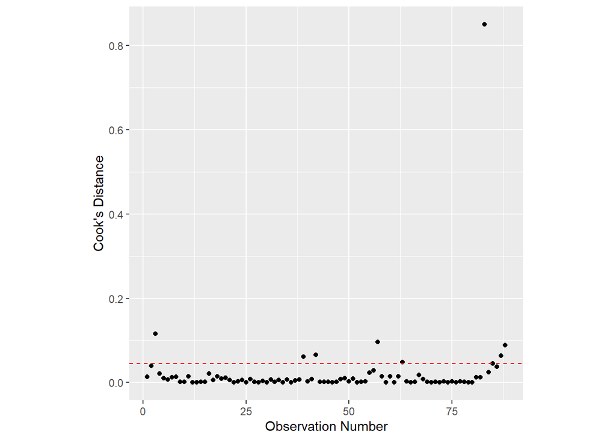

```r
gdp_data$cooksd <- cooks.distance(gdp_lm_subset)

# plot Cook's distance against the observation number
ggplot(data = gdp_data) +
  geom_point(mapping = aes(x = as.numeric(rownames(gdp_data)),
                           y = cooksd)) +
  ylab("Cook's Distance") +
  xlab("Observation Number") +
  geom_hline(mapping = aes(yintercept = 4 / length(cooksd)),
             color = "red",
             linetype = "dashed") +
  theme(aspect.ratio = 1)
```

#### 22. Is multicollinearity still an issue?

```r
gdp_vif_subset <- vif(gdp_lm_subset)
gdp_vif_subset
```

```
##   GGCFD3    GVR61  IPRICE1   MINING MUSLIM00  OTHFRAC      P60    SPAIN
## 1.558048 1.584790 1.352251 1.435171 1.691311 1.714366 2.549977 1.694250
## TROPICAR  YRSOPEN
## 1.660188 2.014355
```

```r
max(gdp_vif_subset)
```

```
## [1] 2.549977
```

```r
mean(gdp_vif_subset)
```

```
## [1] 1.725471
```

Based on our new model, mulitcolinearity does not appear to be a problem as there are no vifs that are greater than 5.

#### 23. Briefly summarize what you learned, personally, from this analysis about the statistics, model fitting process, etc.

I learned how to use different selection methods to get adequate models that do not use the best subsets variable selection as that can often take an unacceptable amount of time to compute. I also learned how to determine which varaibles are best to select given the models that can be constructed from various selection methods.